### R/sl4hm: Simulated Likelihood for modelling household epidemics

[Yair Goldberg](https://yairgo.net.technion.ac.il/) and Rami Yaari

[R/sl4hm](https://github.com/yairgoldy/sl4hm) is an R package. This package implements simulations of epidemics within households of children and adults and calculates the likelihood of a set of transmission parameters given a dataset of the result of epidemics (number of infected children and adults) within households.

#### Installation

You can install it from its [GitHub repository](https://github.com/yairgoldy/sl4hm). You first need to install the devtools package.

```r
install.packages("devtools")
```

Then install R/sl4hm using the `install_github` function in the devtools package.

```r
library(devtools)
install_github("yairgoldy/sl4hm")
```

### The data

Loading the data used for the analysis and saving it to a csv file ca can be done as follows.

```r
library(sl4hm)
household_data
```

```
## # A tibble: 637 x 7
##     size adults childs pos.adults pos.childs duration idnex.case.is.adult.prob
##    <int>  <int>  <int>      <int>      <int>    <dbl>                    <dbl>
##  1     2      2      0          1          0       12                    1
##  2     6      2      4          2          0       26                    1
##  3     4      4      0          4          0       44                    1
##  4     8      2      6          2          4       17                    1
##  5     8      2      6          2          3       28                    0.667
##  6     2      2      0          2          0       15                    1
##  7     2      2      0          1          0       23                    1
##  8     2      2      0          1          0        9                    1
##  9     7      4      3          1          0        7                    1
## 10    12      4      8          2          2       35                    1
## # ... with 627 more rows
```

```r
write.csv(x = household_data,file = "household_data.csv")
```

The more detailed individualized-data level of the household data can be downloaded directly from this GitHub repository.

#### Example use

First create a dataset in which each row corresponds to a family and includes the number of adults and children and the index case.

```r
family_structure_data <- create_family_structure_data(n=1000)
head(family_structure_data,n = 5)
```

```
## # A tibble: 5 x 4
##   adults childs first.is.adult   day
##    <dbl>  <dbl> <lgl>          <dbl>
## 1      1      4 FALSE             21
## 2      1      2 TRUE              21
## 3      3      0 TRUE              21
## 4      5      2 TRUE              21
## 5      1      5 TRUE              21
```

Then simulate the epidemic dynamic within each household, given the transmission matrix for children and adults (beta) and a generation time distribution (P). The returned dataset includes the number of infected adults and children in each household.

```r
dat <- create_simulated_data(family_structure_data = family_structure_data,
                             beta_cc = 0.1,
                             beta_ca = 0.2,
                             beta_ac = 0.2,
                             beta_aa = 0.4,
                             P=sl4hm::load_P())
head(dat,n = 5)
```

```
## # A tibble: 5 x 8
##   adults childs first.is.adult   day index pos.adults pos.childs findex
##    <dbl>  <dbl> <lgl>          <int> <dbl>      <dbl>      <dbl>  <int>
## 1      1      4 FALSE             21     1          0          3      1
## 2      1      2 TRUE              21     1          1          0      2
## 3      3      0 TRUE              21     1          3          0      3
## 4      5      2 TRUE              21     1          2          0      4
## 5      1      5 TRUE              21     1          1          2      5
```

Calculate the likelihood surface for this dataset. While the simulated data can be generated with any combination of beta values, the likelihood function assumes a unique structure of beta in which beta_ac=beta_aa*delta, beta_ca=beta_aa*gamma, and beta_cc=beta_aa*delta*gamma, where gamma and delta are non-negative coeficients measuring the susceptibility and infectivity of children compared to adults. The likelihood is calculated for a coarse grid. One can download a dictionary [from here](https://technionmail-my.sharepoint.com/:f:/g/personal/yairgo_technion_ac_il/EoMePBbpQkxLkju-mi51-ywB8pVeWgiEFY99IpHFtynjbw?e=dgVBUk) which enables calculating the likelihood on a finer grid. This dictionary holds the distribution of the number of infected for each family type and duration of epidemic. One can also create a dictionary using the function `family_dictionary`.

```r
lik <- calc_likelihood(dat)
head(lik,5)
```

```
## # A tibble: 5 x 4
##   beta_aa gamma_val delta_val   nll
##     <dbl>     <dbl>     <dbl> <dbl>
## 1    0.25       0.4       0.4 1656.
## 2    0.25       0.4       0.5 1628.
## 3    0.25       0.4       0.6 1616.
## 4    0.25       0.5       0.4 1598.
## 5    0.25       0.5       0.5 1567.
```

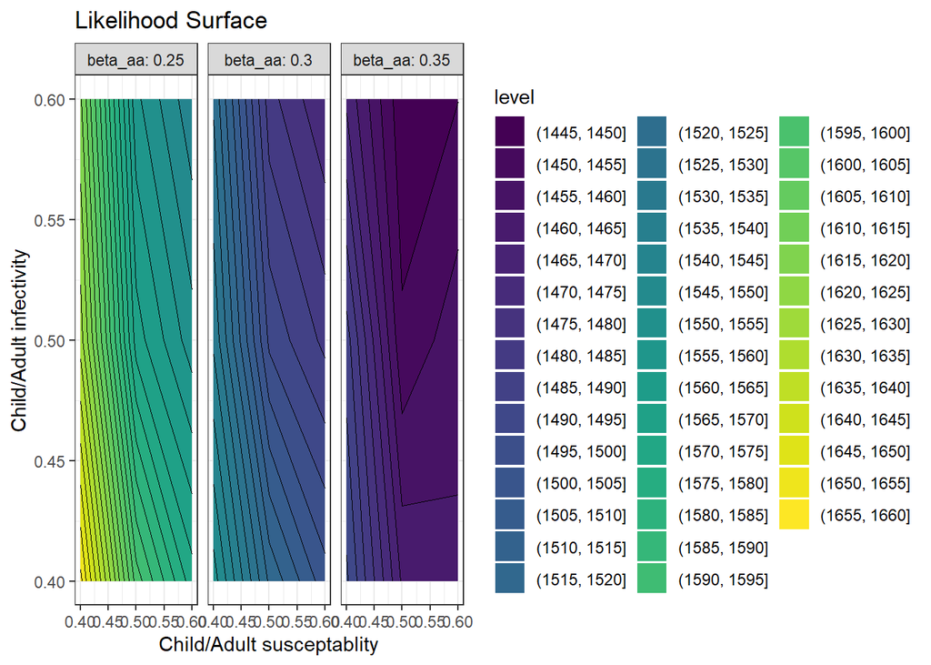

```r
require(ggplot2,quietly = T)

ggplot(lik,aes(x=gamma_val,y=delta_val,z=nll))+
  facet_wrap(~beta_aa,labeller="label_both", ncol=3)+
  geom_contour_filled(binwidth=5)+
  geom_contour(color = "black", size = 0.1,binwidth=5) +
  xlab("Child/Adult susceptablity")+
  ylab("Child/Adult infectivity")+
ggtitle("Likelihood Surface")+
 theme_bw()
```

Using the function `run_simulation` one can create multiple datasets and find the MLE for each dataset. This can be used for calculating bootstrap confidence intervals for the parameters.